# TRGN510_final-project

## Introduction

RNA-sequencing is one of the prominent technologies used for gene expression profiling. For this markdown, an edgeR - limma workflow for analyzing RNA-seq counts data is used. Pre-processing and exploring of the data will be performed, and differentially expressed genes will be analyzed using plots and statistics. The analysis performed in this markdown will be based on two groups of patients with varying stages of breast cancer. Both group consists of 20 females, with one group made up of Asians and the second group made up of Caucasians (white).

## Load in the required packages

The necessary packages to perform the analyses will first be loaded into R.

```r
library(limma)
library(Glimma)
library(edgeR)
library(Homo.sapiens)
```

## Loading in the data

There will be 40 files loaded into R, with each file representing one patient. The raw gene counts will also be displayed by the code below.

```r
setwd("~/R_files/510project")

files <- c("00a47e69-ef6a-4be9-827d-d48609859a7e.htseq.counts", "0211f2ea-a4f6-4a57-8f98-66bf0a327479.htseq.counts", "0abe1897-c3a9-47e5-8a59-e5a2232b23db.htseq.counts", "23f8f5e2-25b8-4b43-b939-66e7e3f55977.htseq.counts", "36d40974-4d4f-4726-b98f-1ceab329d0bf.htseq.counts", "45c4eed7-f80d-4d33-abbb-321ff5ed0750.htseq.counts", "4ba6c212-ef90-4ab3-b551-35c05cb6df90.htseq.counts", "54401c2a-7124-42b7-90d8-6267575bce51.htseq.counts", "5fbf674e-49f3-4af8-9c9c-20a528ad0684.htseq.counts", "6515c0f7-2334-4bad-bde7-b562f5f67148.htseq.counts", "68b3162f-a77a-4630-a64a-26a33a2ecb12.htseq.counts", "6f618400-b914-4103-bf46-9c026b470aa0.htseq.counts", "7d229eb4-cdbd-4578-9e54-c7cbd7ef1378.htseq.counts", "7d83af5d-9bcf-4c82-a993-fa9053a9b3cb.htseq.counts", "8a244dd2-0dc1-429c-81a1-5873ce536b47.htseq.counts", "a8a58442-78f5-4876-b25e-c04339eb6f26.htseq.counts", "aa08f8f5-e41d-4987-aa65-5cfe5fedeb1b.htseq.counts", "b667a6ae-353f-4045-a442-a4320231ed73.htseq.counts", "d6608d24-28bc-4d51-b6d8-8fec450a858f.htseq.counts", "dc322491-2407-401e-a422-96be40d6518f.htseq.counts", "0827bd64-de4e-45bc-9e75-a9bdce41f4a5.htseq.counts", "1d102e83-ede2-460e-ab2e-f42d8db6970e.htseq.counts", "34dd2d8f-6b3c-42ec-94c6-2c3eb75e8b91.htseq.counts", "37c712b1-00b7-4db2-8728-88816e06bbdd.htseq.counts", "3f9f9a93-3270-462b-a014-567f98a963cf.htseq.counts", "4253d955-2f01-4657-909e-756c899dd81d.htseq.counts", "4a775326-e623-47d4-b105-d32fc21afb8a.htseq.counts", "4fd01cd7-7ff5-4570-891e-747a0c640ddc.htseq.counts", "68872445-c6f8-4e6a-b0b3-dcaa53e70e56.htseq.counts", "7eed3c23-853b-4d0e-9b2d-81990f2ca0c6.htseq.counts", "891fa657-fa9c-46b3-b751-e337d88e08ae.htseq.counts", "8fd4ceba-6ad2-4726-bf8b-f0316640305c.htseq.counts", "96ddce60-2be5-4f57-814b-35722aa00fd9.htseq.counts", "be0d2e41-7373-4fa9-9c05-877e9ddcb88c.htseq.counts", "cf1a1478-68c1-431b-86cb-c4ddb105accf.htseq.counts", "d70033a1-9000-493f-9474-6e9e3f47b851.htseq.counts", "d806b4fb-807b-4d66-b17f-c2e381675e4f.htseq.counts", "d9b4ed1e-39fe-4378-a9f8-f5f74a284c57.htseq.counts", "e3067466-096f-4bea-993f-b0469a7e11e3.htseq.counts", "ef9be0f1-2a17-49b9-b90e-2bb2e4f43c84.htseq.counts")

read.delim(files[1], nrow=5, header=FALSE)
```

```
##                   V1   V2
## 1 ENSG00000000003.13  846
## 2  ENSG00000000005.5    2
## 3 ENSG00000000419.11 1078
## 4 ENSG00000000457.12 2222
## 5 ENSG00000000460.15  896
```

```r
getwd()
```

```
## [1] "/Users/keithleung/R_files/510project"
```

The data has been loaded in successfully.

## Grouping the data

The contents of each file is combined into one data frame called as ‘x’. The data is grouped according to the parameter of ethnicity: white vs. Asian. EdgeR provides a simplified method of doing this with a single command: readDGE.

```r
x <- readDGE(files, columns=c(1,2))
```

```
## Meta tags detected: __no_feature, __ambiguous, __too_low_aQual, __not_aligned, __alignment_not_unique
```

```r
class(x)
```

```
## [1] "DGEList"
## attr(,"package")
## [1] "edgeR"
```

The newly created dataframe “x” can be checked for its dimensions to see if the readDGE command worked.

```r
dim(x)
```

```
## [1] 60487    40
```

The dim function shows that there are 60487 rows (which represents genes) and 40 columns. The 40 columns represents the 40 files (20 Asian females and 20 white females).

The code block below will help to label all the columns in data frame “x” according to the respective files.

```r
samplenames<-colnames(x)
sampleNames
```

[output not shown]

```r
colnames(x) <- samplenames
```

## Organizing the data

For later analysis, sample-level information related to the experimental design needs to be associated with the columns of the counts matrix. The code below will help to group the files within the data frame according to the patient ethnicity. The tumor grade, with “high” representing stage III or IV cancer and “low” representing stage I or II cancer, for each patient file will also be defined in the “x” DGEList-object.

```r
group <- c(rep("Asian",20), rep("white",20))
x$samples$group <- group
tumorgrade <- c("low", "high", "low", "low", "low", "low", "low", "low", "low", "low",
                "low", "high", "low", "low", "low", "high", "low", "low", "low", "high",
                "low", "low", "low", "high", "low", "low", "low", "low", "low", "low",
                "high", "low", "high", "low", "low", "low", "low", "low", "high", "low")
x$samples$tumorgrade <- tumorgrade
x$samples
```

```
##                                                                                        files
## 00a47e69-ef6a-4be9-827d-d48609859a7e.htseq 00a47e69-ef6a-4be9-827d-d48609859a7e.htseq.counts
## 0211f2ea-a4f6-4a57-8f98-66bf0a327479.htseq 0211f2ea-a4f6-4a57-8f98-66bf0a327479.htseq.counts
## 0abe1897-c3a9-47e5-8a59-e5a2232b23db.htseq 0abe1897-c3a9-47e5-8a59-e5a2232b23db.htseq.counts
## 23f8f5e2-25b8-4b43-b939-66e7e3f55977.htseq 23f8f5e2-25b8-4b43-b939-66e7e3f55977.htseq.counts
## 36d40974-4d4f-4726-b98f-1ceab329d0bf.htseq 36d40974-4d4f-4726-b98f-1ceab329d0bf.htseq.counts
## 45c4eed7-f80d-4d33-abbb-321ff5ed0750.htseq 45c4eed7-f80d-4d33-abbb-321ff5ed0750.htseq.counts
## 4ba6c212-ef90-4ab3-b551-35c05cb6df90.htseq 4ba6c212-ef90-4ab3-b551-35c05cb6df90.htseq.counts
## 54401c2a-7124-42b7-90d8-6267575bce51.htseq 54401c2a-7124-42b7-90d8-6267575bce51.htseq.counts
## 5fbf674e-49f3-4af8-9c9c-20a528ad0684.htseq 5fbf674e-49f3-4af8-9c9c-20a528ad0684.htseq.counts
## 6515c0f7-2334-4bad-bde7-b562f5f67148.htseq 6515c0f7-2334-4bad-bde7-b562f5f67148.htseq.counts
## 68b3162f-a77a-4630-a64a-26a33a2ecb12.htseq 68b3162f-a77a-4630-a64a-26a33a2ecb12.htseq.counts
## 6f618400-b914-4103-bf46-9c026b470aa0.htseq 6f618400-b914-4103-bf46-9c026b470aa0.htseq.counts
## 7d229eb4-cdbd-4578-9e54-c7cbd7ef1378.htseq 7d229eb4-cdbd-4578-9e54-c7cbd7ef1378.htseq.counts
## 7d83af5d-9bcf-4c82-a993-fa9053a9b3cb.htseq 7d83af5d-9bcf-4c82-a993-fa9053a9b3cb.htseq.counts
## 8a244dd2-0dc1-429c-81a1-5873ce536b47.htseq 8a244dd2-0dc1-429c-81a1-5873ce536b47.htseq.counts
## a8a58442-78f5-4876-b25e-c04339eb6f26.htseq a8a58442-78f5-4876-b25e-c04339eb6f26.htseq.counts
## aa08f8f5-e41d-4987-aa65-5cfe5fedeb1b.htseq aa08f8f5-e41d-4987-aa65-5cfe5fedeb1b.htseq.counts
## b667a6ae-353f-4045-a442-a4320231ed73.htseq b667a6ae-353f-4045-a442-a4320231ed73.htseq.counts
## d6608d24-28bc-4d51-b6d8-8fec450a858f.htseq d6608d24-28bc-4d51-b6d8-8fec450a858f.htseq.counts
## dc322491-2407-401e-a422-96be40d6518f.htseq dc322491-2407-401e-a422-96be40d6518f.htseq.counts
## 0827bd64-de4e-45bc-9e75-a9bdce41f4a5.htseq 0827bd64-de4e-45bc-9e75-a9bdce41f4a5.htseq.counts
## 1d102e83-ede2-460e-ab2e-f42d8db6970e.htseq 1d102e83-ede2-460e-ab2e-f42d8db6970e.htseq.counts
## 34dd2d8f-6b3c-42ec-94c6-2c3eb75e8b91.htseq 34dd2d8f-6b3c-42ec-94c6-2c3eb75e8b91.htseq.counts
## 37c712b1-00b7-4db2-8728-88816e06bbdd.htseq 37c712b1-00b7-4db2-8728-88816e06bbdd.htseq.counts
## 3f9f9a93-3270-462b-a014-567f98a963cf.htseq 3f9f9a93-3270-462b-a014-567f98a963cf.htseq.counts
## 4253d955-2f01-4657-909e-756c899dd81d.htseq 4253d955-2f01-4657-909e-756c899dd81d.htseq.counts
## 4a775326-e623-47d4-b105-d32fc21afb8a.htseq 4a775326-e623-47d4-b105-d32fc21afb8a.htseq.counts
## 4fd01cd7-7ff5-4570-891e-747a0c640ddc.htseq 4fd01cd7-7ff5-4570-891e-747a0c640ddc.htseq.counts
## 68872445-c6f8-4e6a-b0b3-dcaa53e70e56.htseq 68872445-c6f8-4e6a-b0b3-dcaa53e70e56.htseq.counts
## 7eed3c23-853b-4d0e-9b2d-81990f2ca0c6.htseq 7eed3c23-853b-4d0e-9b2d-81990f2ca0c6.htseq.counts
## 891fa657-fa9c-46b3-b751-e337d88e08ae.htseq 891fa657-fa9c-46b3-b751-e337d88e08ae.htseq.counts
## 8fd4ceba-6ad2-4726-bf8b-f0316640305c.htseq 8fd4ceba-6ad2-4726-bf8b-f0316640305c.htseq.counts
## 96ddce60-2be5-4f57-814b-35722aa00fd9.htseq 96ddce60-2be5-4f57-814b-35722aa00fd9.htseq.counts
## be0d2e41-7373-4fa9-9c05-877e9ddcb88c.htseq be0d2e41-7373-4fa9-9c05-877e9ddcb88c.htseq.counts
## cf1a1478-68c1-431b-86cb-c4ddb105accf.htseq cf1a1478-68c1-431b-86cb-c4ddb105accf.htseq.counts
## d70033a1-9000-493f-9474-6e9e3f47b851.htseq d70033a1-9000-493f-9474-6e9e3f47b851.htseq.counts
## d806b4fb-807b-4d66-b17f-c2e381675e4f.htseq d806b4fb-807b-4d66-b17f-c2e381675e4f.htseq.counts
## d9b4ed1e-39fe-4378-a9f8-f5f74a284c57.htseq d9b4ed1e-39fe-4378-a9f8-f5f74a284c57.htseq.counts
## e3067466-096f-4bea-993f-b0469a7e11e3.htseq e3067466-096f-4bea-993f-b0469a7e11e3.htseq.counts
```

[output cut: 68 more lines]

```
## 4253d955-2f01-4657-909e-756c899dd81d.htseq        low
## 4a775326-e623-47d4-b105-d32fc21afb8a.htseq        low
## 4fd01cd7-7ff5-4570-891e-747a0c640ddc.htseq        low
## 68872445-c6f8-4e6a-b0b3-dcaa53e70e56.htseq        low
## 7eed3c23-853b-4d0e-9b2d-81990f2ca0c6.htseq        low
## 891fa657-fa9c-46b3-b751-e337d88e08ae.htseq       high
## 8fd4ceba-6ad2-4726-bf8b-f0316640305c.htseq        low
## 96ddce60-2be5-4f57-814b-35722aa00fd9.htseq       high
## be0d2e41-7373-4fa9-9c05-877e9ddcb88c.htseq        low
## cf1a1478-68c1-431b-86cb-c4ddb105accf.htseq        low
## d70033a1-9000-493f-9474-6e9e3f47b851.htseq        low
## d806b4fb-807b-4d66-b17f-c2e381675e4f.htseq        low
## d9b4ed1e-39fe-4378-a9f8-f5f74a284c57.htseq        low
## e3067466-096f-4bea-993f-b0469a7e11e3.htseq       high
## ef9be0f1-2a17-49b9-b90e-2bb2e4f43c84.htseq        low
```

Because the “Homo.sapiens” package does not contain the ENSEMBL Gene ID in the format provided by the loaded data, the data must be converted using a substitution function. The digits following the decimal are replaced to match with the key.

```r
library(gsubfn)
geneid <- rownames(x)
geneid <-gsub("\\.[0-9]*$","", geneid)
head(geneid)
```

```
## [1] "ENSG00000000005" "ENSG00000000419" "ENSG00000000457" "ENSG00000000460"
## [5] "ENSG00000000938" "ENSG00000000971"
```

The “genes” data frame is used to store the gene-level information corresponding to the rows of genes in our patient data files. The information required for this data frame is retrieved from the ‘Homo.sapiens’ library. The GeneIDs are associated with the symbol and the chromosome number of each gene.

```r
genes <- select(Homo.sapiens, keys=geneid, columns=c("SYMBOL", "TXCHROM"),
                keytype="ENSEMBL")
head(genes)
```

```
##           ENSEMBL   SYMBOL TXCHROM
## 1 ENSG00000000005     TNMD    chrX
## 2 ENSG00000000419     DPM1   chr20
## 3 ENSG00000000457    SCYL3    chr1
## 4 ENSG00000000460 C1orf112    chr1
## 5 ENSG00000000938      FGR    chr1
## 6 ENSG00000000971      CFH    chr1
```

Any duplicated genes are removed from the dataset.

```r
genes <- genes[!duplicated(genes$ENSEMBL),]
x$genes <- genes
x
```

```
## An object of class "DGEList"
## $samples
##                                                                                        files
## 00a47e69-ef6a-4be9-827d-d48609859a7e.htseq 00a47e69-ef6a-4be9-827d-d48609859a7e.htseq.counts
## 0211f2ea-a4f6-4a57-8f98-66bf0a327479.htseq 0211f2ea-a4f6-4a57-8f98-66bf0a327479.htseq.counts
## 0abe1897-c3a9-47e5-8a59-e5a2232b23db.htseq 0abe1897-c3a9-47e5-8a59-e5a2232b23db.htseq.counts
## 23f8f5e2-25b8-4b43-b939-66e7e3f55977.htseq 23f8f5e2-25b8-4b43-b939-66e7e3f55977.htseq.counts
## 36d40974-4d4f-4726-b98f-1ceab329d0bf.htseq 36d40974-4d4f-4726-b98f-1ceab329d0bf.htseq.counts
##                                            group lib.size norm.factors
## 00a47e69-ef6a-4be9-827d-d48609859a7e.htseq Asian 63889146            1
## 0211f2ea-a4f6-4a57-8f98-66bf0a327479.htseq Asian 72976884            1
## 0abe1897-c3a9-47e5-8a59-e5a2232b23db.htseq Asian 69154937            1
## 23f8f5e2-25b8-4b43-b939-66e7e3f55977.htseq Asian 86707490            1
## 36d40974-4d4f-4726-b98f-1ceab329d0bf.htseq Asian 80628928            1
##                                            tumorgrade
## 00a47e69-ef6a-4be9-827d-d48609859a7e.htseq        low
## 0211f2ea-a4f6-4a57-8f98-66bf0a327479.htseq       high
## 0abe1897-c3a9-47e5-8a59-e5a2232b23db.htseq        low
## 23f8f5e2-25b8-4b43-b939-66e7e3f55977.htseq        low
## 36d40974-4d4f-4726-b98f-1ceab329d0bf.htseq        low
## 35 more rows ...
##
## $counts
##                     Samples
## Tags                 00a47e69-ef6a-4be9-827d-d48609859a7e.htseq
##   ENSG00000000005.5                                           2
##   ENSG00000000419.11                                       1078
##   ENSG00000000457.12                                       2222
##   ENSG00000000460.15                                        896
##   ENSG00000000938.11                                        272
##                     Samples
## Tags                 0211f2ea-a4f6-4a57-8f98-66bf0a327479.htseq
##   ENSG00000000005.5                                           2
##   ENSG00000000419.11                                       2358
##   ENSG00000000457.12                                       1241
##   ENSG00000000460.15                                        389
##   ENSG00000000938.11                                        542
##                     Samples
## Tags                 0abe1897-c3a9-47e5-8a59-e5a2232b23db.htseq
##   ENSG00000000005.5                                           1
```

[output cut: 258 more lines]

```
##   ENSG00000000005.5                                          87
##   ENSG00000000419.11                                       1732
##   ENSG00000000457.12                                       2521
##   ENSG00000000460.15                                        678
##   ENSG00000000938.11                                       3030
## 60482 more rows ...
##
## $genes
##           ENSEMBL   SYMBOL TXCHROM
## 1 ENSG00000000005     TNMD    chrX
## 2 ENSG00000000419     DPM1   chr20
## 3 ENSG00000000457    SCYL3    chr1
## 4 ENSG00000000460 C1orf112    chr1
## 5 ENSG00000000938      FGR    chr1
## 60482 more rows ...
```

## Transformations from the raw scale

The data is transformed from its raw form to a more useable one. The calculations of “cpm: counts per million” and “lcpm: log of counts per million” are carried out to do so.

```r
cpm <- cpm(x)
lcpm <- cpm(x, log=TRUE)
```

For further calculations the data is processed using the calculations below. L is the average library size in millions. M is the median of the library size in millions.

```r
L <- mean(x$samples$lib.size) * 1e-6
M <- median(x$samples$lib.size) * 1e-6
c(L, M)
```

```
## [1] 92.39128 87.39270
```

The summary of the lcpm calculation is shown below.

```r
summary(lcpm)
```

```
##  00a47e69-ef6a-4be9-827d-d48609859a7e.htseq
##  Min.   :-5.5297
##  1st Qu.:-5.5297
##  Median :-5.5297
##  Mean   :-2.7300
##  3rd Qu.:-0.6618
##  Max.   :17.7232
##  0211f2ea-a4f6-4a57-8f98-66bf0a327479.htseq
##  Min.   :-5.530
##  1st Qu.:-5.530
##  Median :-4.822
##  Mean   :-2.490
##  3rd Qu.: 0.143
##  Max.   :17.808
##  0abe1897-c3a9-47e5-8a59-e5a2232b23db.htseq
##  Min.   :-5.5297
##  1st Qu.:-5.5297
##  Median :-4.7916
##  Mean   :-2.6371
##  3rd Qu.:-0.3437
##  Max.   :17.6708
##  23f8f5e2-25b8-4b43-b939-66e7e3f55977.htseq
##  Min.   :-5.530
##  1st Qu.:-5.530
##  Median :-4.914
##  Mean   :-2.564
##  3rd Qu.:-0.231
##  Max.   :17.332
##  36d40974-4d4f-4726-b98f-1ceab329d0bf.htseq
##  Min.   :-5.52968
##  1st Qu.:-5.52968
##  Median :-4.87622
##  Mean   :-2.53418
##  3rd Qu.:-0.05254
##  Max.   :17.71165
##  45c4eed7-f80d-4d33-abbb-321ff5ed0750.htseq
##  Min.   :-5.5297
##  1st Qu.:-5.5297
##  Median :-4.6815
##  Mean   :-2.5055
```

[output cut: 225 more lines]

```
##  Max.   :17.701
##  e3067466-096f-4bea-993f-b0469a7e11e3.htseq
##  Min.   :-5.5297
##  1st Qu.:-5.5297
##  Median :-4.9103
##  Mean   :-2.6212
##  3rd Qu.:-0.4777
##  Max.   :17.4991
##  ef9be0f1-2a17-49b9-b90e-2bb2e4f43c84.htseq
##  Min.   :-5.5297
##  1st Qu.:-5.5297
##  Median :-4.9000
##  Mean   :-2.5494
##  3rd Qu.:-0.1548
##  Max.   :17.5508
```

## Removing genes that are lowly expressed

Some genes are lowly expressed and do not contribute to the statistical analysis in a meaningful manner. These are genes that are lowly expressed in both of the data groups. To understand the ratio of these genes, the following line is run:

```r
table(rowSums(x$counts==0)==9)
```

```
##
## FALSE  TRUE
## 59997   490
```

EdgeR helps to filter out these lowly expressed genes rather easily:

```r
keep.exprs <- filterByExpr(x, group=group)
x <- x[keep.exprs,, keep.lib.sizes=FALSE]
dim(x)
```

```
## [1] 20886    40
```

The number of genes used for interpretation are reduced from the 60,487 to 20886. The filtered versus unfiltered data is presented in a graphical manner using the following lines of code. The package “RColorBrewer” is used to help create the graphs. After filtering the data, it can be seen that the plot gets smoothed out.

```r
lcpm.cutoff <- log2(10/M + 2/L)
library(RColorBrewer)
nsamples <- ncol(x)
col <- brewer.pal(nsamples, "Paired")
```

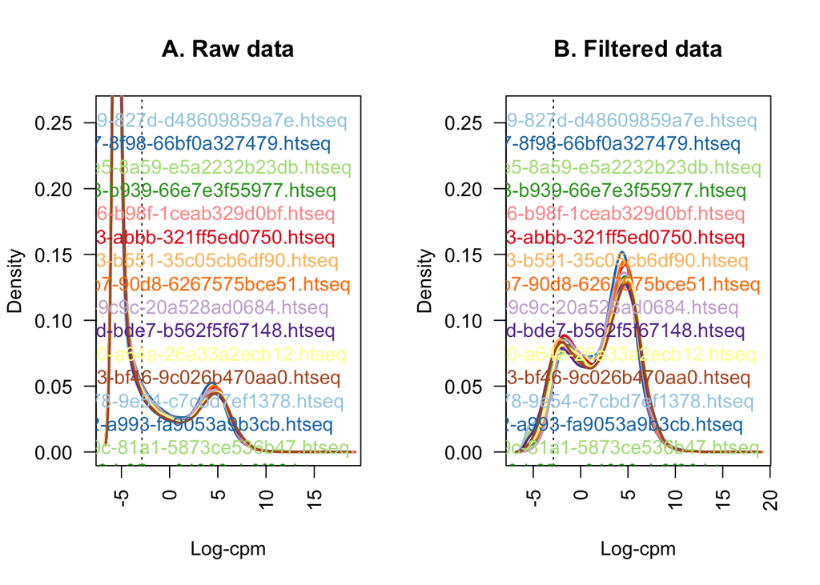

```r
par(mfrow=c(1,2))
plot(density(lcpm[,1]), col=col[1], lwd=2, ylim=c(0,0.26), las=2, main="", xlab="")
title(main="A. Raw data", xlab="Log-cpm")
abline(v=lcpm.cutoff, lty=3)
for (i in 2:nsamples){
den <- density(lcpm[,i])
lines(den$x, den$y, col=col[i], lwd=2)
}
legend("topright", samplenames, text.col=col, bty="n")
lcpm <- cpm(x, log=TRUE)
plot(density(lcpm[,1]), col=col[1], lwd=2, ylim=c(0,0.26), las=2, main="", xlab="")
title(main="B. Filtered data", xlab="Log-cpm")
abline(v=lcpm.cutoff, lty=3)
for (i in 2:nsamples){
den <- density(lcpm[,i])
lines(den$x, den$y, col=col[i], lwd=2)
}
legend("topright", samplenames, text.col=col, bty="n")
```

## Normalizing gene expression distributions

For statistical analysis, the normalization of data is greatly beneficial. Normalization should be performed to ensure that the expression distributions of each sample are similar across the entire experiment. edgeR offers a function to do this. The resulting values are stored in a data set called norm.factors.

```r
x <- calcNormFactors(x, method = "TMM")
x$samples$norm.factors
```

```
##  [1] 1.0032234 1.0249509 1.0562917 1.1129549 1.1226787 1.1167543 0.9596554
##  [8] 1.1044366 1.1364243 0.9686791 1.1551560 1.0330608 1.0444397 1.1166399
## [15] 0.6367315 0.8413959 0.8967112 0.9740954 0.8563486 0.9988445 1.0334991
## [22] 1.1014337 1.0140630 1.2868320 0.9065866 0.9438617 0.5562950 1.0281427
## [29] 0.7430484 0.9048054 1.2171299 1.1786699 1.2897168 1.1186813 1.2956297
## [36] 0.9018703 0.7829183 0.9488794 1.0550795 1.0956067
```

```r
x2 <- x
x2$samples$norm.factors <- 1
x2$counts[,1] <- ceiling(x2$counts[,1]*0.05)
x2$counts[,2] <- x2$counts[,2]*5
```

The plots below shows data that is normalized versus non-normalized.

```
##  [1] 0.06040247 5.23226865 1.05829399 1.13995563 1.14445531 1.14447816
##  [7] 0.97483893 1.13875921 1.17733889 1.02103250 1.18219006 1.07217389
## [13] 1.07999712 1.13534410 0.65901996 0.86361084 0.94490536 1.02294536
## [19] 0.88730198 1.02364120 1.07365624 1.15961706 1.02479751 1.32930060
## [25] 0.92453832 0.98027370 0.58016613 1.07201738 0.77764773 0.91693516
## [31] 1.27342305 1.19455441 1.35544646 1.13132881 1.34929183 0.95392423
## [37] 0.79656738 0.99029032 1.06455315 1.12423850
```

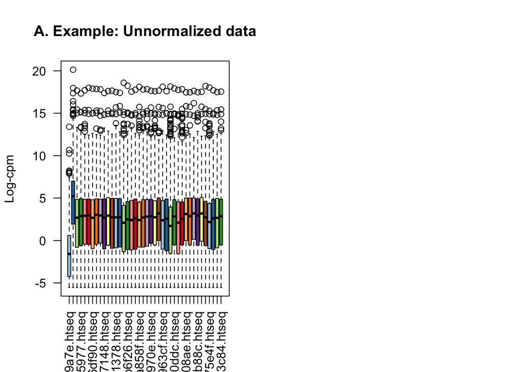

```r
par(mfrow=c(1,2))
lcpm <- cpm(x2, log=TRUE)
boxplot(lcpm, las=2, col=col, main="")
title(main="A. Example: Unnormalized data",ylab="Log-cpm")
x2 <- calcNormFactors(x2)
x2$samples$norm.factors
```

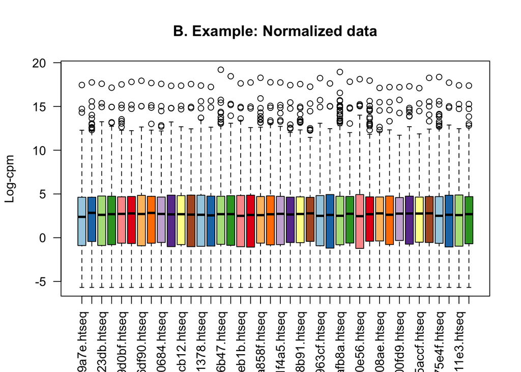

```r
lcpm <- cpm(x2, log=TRUE)
boxplot(lcpm, las=2, col=col, main="")
title(main="B. Example: Normalized data",ylab="Log-cpm")
```

## Unsupervised clustering of samples

The MDS plot is an informative representation of the similarities and dissimilarities in a sample. The extent of the differences can give an idea of the expected results of the differential expression analysis. The plotMDS function of limma allows us to create the graph. The distances on the plot correspond to the action of different categories on this data. There are two plots here: one that compares the two ethnic groups “Asian” vs “white”, and one that compares the tumor grade “high” vs “low”.

```r
lcpm <- cpm(x, log=TRUE)
par(mfrow=c(1,2))
col.group <- group
levels(col.group) <-  brewer.pal(nlevels(col.group), "Set1")
col.group <- as.character(col.group)
col.tumorgrade <- tumorgrade
levels(col.tumorgrade) <-  brewer.pal(nlevels(col.tumorgrade), "Set2")
```

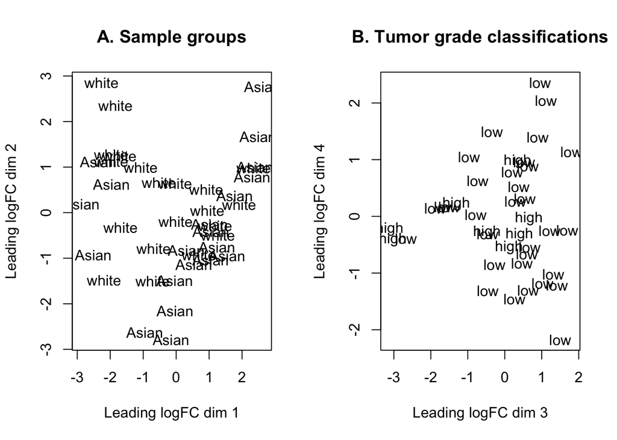

```r
col.tumorgrade <- as.character(col.tumorgrade)
col.group <- c("purple","orange")[group]
col.tumorgrade <- c("red","blue")[tumorgrade]
plotMDS(lcpm, labels=group, col=col.group)
title(main="A. Sample groups")
plotMDS(lcpm, labels=tumorgrade, col=col.tumorgrade, dim=c(3,4))
title(main="B. Tumor grade classifications")
```

Glimma can be used to create an interactive version of the plots above.

```r
glMDSPlot(lcpm, labels=paste(group, tumorgrade, sep="_"),
          groups=x$samples[,c(2,5)], launch=TRUE)
```

# Differential expression analyses

## Creating a design matrix and contrasts

To begin differential expression analysis, a design matrix with both the Asian group of data and white group of data needs to be created. Another column within the matrix, which details the co-variate “tumor grade” will also be generated.

```r
design <- model.matrix(~0+group+tumorgrade)
colnames(design) <- gsub("group", "", colnames(design))
design
```

```
##    Asian white tumorgradelow
## 1      1     0             1
## 2      1     0             0
## 3      1     0             1
## 4      1     0             1
## 5      1     0             1
## 6      1     0             1
## 7      1     0             1
## 8      1     0             1
## 9      1     0             1
## 10     1     0             1
## 11     1     0             1
## 12     1     0             0
## 13     1     0             1
## 14     1     0             1
```

[output cut: 34 more lines]

Contrasts for the two groups are stored within a matrix:

```r
contr.matrix <- makeContrasts(
   AsianVswhite = Asian-white,
   levels = colnames(design))
contr.matrix
```

```
##                Contrasts
## Levels          AsianVswhite
##   Asian                    1
##   white                   -1
##   tumorgradelow            0
```

## Removing heteroscedascity from count data

Voom is a function within limma that allows the raw counts data to be transformed into the normalized data that accommodates the mean-variance relationship.

```
## An object of class "EList"
## $genes
##           ENSEMBL   SYMBOL TXCHROM
## 2 ENSG00000000419     DPM1   chr20
## 3 ENSG00000000457    SCYL3    chr1
## 4 ENSG00000000460 C1orf112    chr1
## 5 ENSG00000000938      FGR    chr1
## 6 ENSG00000000971      CFH    chr1
## 20881 more rows ...
##
## $targets
##                                                                                        files
## 00a47e69-ef6a-4be9-827d-d48609859a7e.htseq 00a47e69-ef6a-4be9-827d-d48609859a7e.htseq.counts
## 0211f2ea-a4f6-4a57-8f98-66bf0a327479.htseq 0211f2ea-a4f6-4a57-8f98-66bf0a327479.htseq.counts
## 0abe1897-c3a9-47e5-8a59-e5a2232b23db.htseq 0abe1897-c3a9-47e5-8a59-e5a2232b23db.htseq.counts
## 23f8f5e2-25b8-4b43-b939-66e7e3f55977.htseq 23f8f5e2-25b8-4b43-b939-66e7e3f55977.htseq.counts
## 36d40974-4d4f-4726-b98f-1ceab329d0bf.htseq 36d40974-4d4f-4726-b98f-1ceab329d0bf.htseq.counts
##                                            group lib.size norm.factors
## 00a47e69-ef6a-4be9-827d-d48609859a7e.htseq Asian 64060507     1.003223
## 0211f2ea-a4f6-4a57-8f98-66bf0a327479.htseq Asian 74605180     1.024951
## 0abe1897-c3a9-47e5-8a59-e5a2232b23db.htseq Asian 72930764     1.056292
## 23f8f5e2-25b8-4b43-b939-66e7e3f55977.htseq Asian 96414383     1.112955
## 36d40974-4d4f-4726-b98f-1ceab329d0bf.htseq Asian 90444865     1.122679
##                                            tumorgrade
## 00a47e69-ef6a-4be9-827d-d48609859a7e.htseq        low
## 0211f2ea-a4f6-4a57-8f98-66bf0a327479.htseq       high
## 0abe1897-c3a9-47e5-8a59-e5a2232b23db.htseq        low
## 23f8f5e2-25b8-4b43-b939-66e7e3f55977.htseq        low
## 36d40974-4d4f-4726-b98f-1ceab329d0bf.htseq        low
## 35 more rows ...
##
## $E
##                     Samples
## Tags                 00a47e69-ef6a-4be9-827d-d48609859a7e.htseq
##   ENSG00000000419.11                                   4.073447
##   ENSG00000000457.12                                   5.116604
##   ENSG00000000460.15                                   3.806796
##   ENSG00000000938.11                                   2.088749
##   ENSG00000000971.14                                   3.848042
##                     Samples
```

[output cut: 300 more lines]

```
## [1,] 2.213164 2.151513 2.129872 1.965855 1.639868 2.031301 2.072818 2.051242
## [2,] 2.185972 2.132475 2.106639 1.935991 1.606604 2.005465 2.031656 2.025089
## [3,] 1.405087 1.538687 1.502611 1.302429 1.065150 1.374205 1.210465 1.397010
## [4,] 1.311542 1.284326 1.254808 1.102409 0.931189 1.155281 1.137344 1.172186
## [5,] 2.345274 2.147408 2.124746 1.959252 1.632495 2.025595 2.292521 2.045466
## 20881 more rows ...
##
## $design
##   Asian white tumorgradelow
## 1     1     0             1
## 2     1     0             0
## 3     1     0             1
## 4     1     0             1
## 5     1     0             1
## 35 more rows ...
```

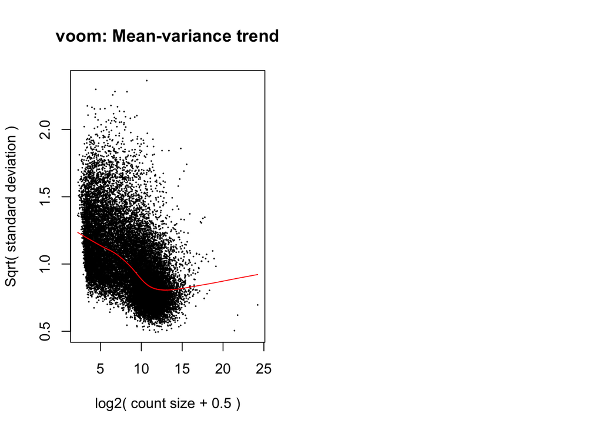

```r
par(mfrow=c(1,2))
v <- voom(x, design, plot=TRUE)
v
```

In these two plots, the relationship between the mean and variances of the data are plot. The first graph represents the relationship before the data is normalized using voom and second, after. The effect of normalization can be visualized through the lines of best fit.

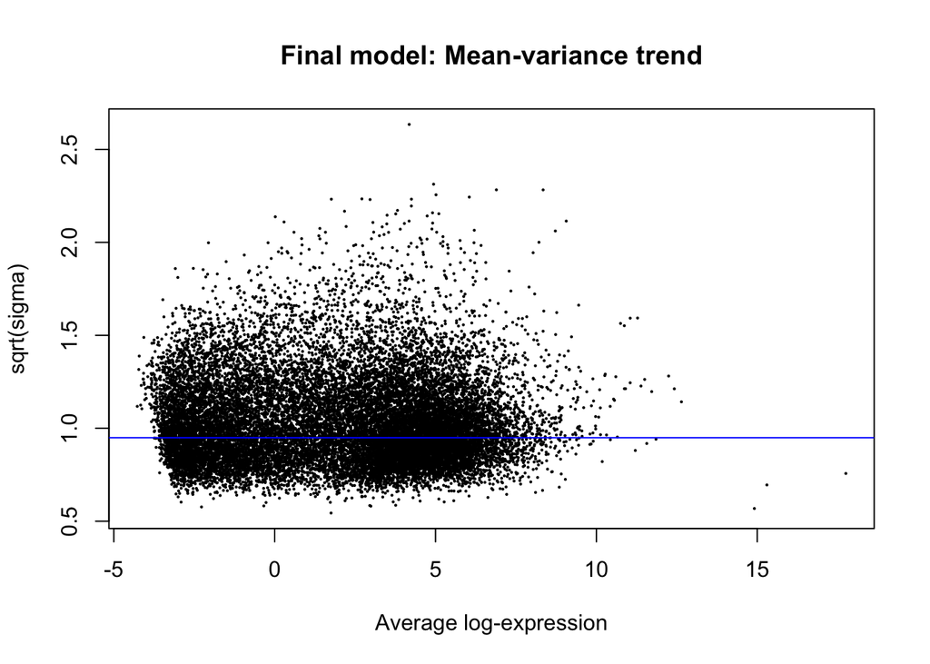

```r
vfit <- lmFit(v, design)
vfit <- contrasts.fit(vfit, contrasts=contr.matrix)
efit <- eBayes(vfit)
plotSA(efit, main="Final model: Mean-variance trend")
```

## Examining the number of differentially expressed genes

T-statistics can be used to help see how many genes are significantly up-regulated or down-regulated. In the table below, we see that 7 genes are down-regulated and 8 genes are up-regulated.

```r
summary(decideTests(efit))
```

```
##        AsianVswhite
## Down              7
## NotSig        20871
## Up                8
```

Additional filtering of significantly DF genes may be done by using the treat method. Here, the filter requires genes to have a log-FC greater than a predetermined value, with the value being set here 0.1. Now, there are 7 genes significantly up-regulated and 5 genes significantly down-regulated.

```r
tfit <- treat(vfit, lfc=0.1)
dt <- decideTests(tfit)
summary(dt)
```

```
##        AsianVswhite
## Down              5
## NotSig        20874
## Up                7
```

All genes, up-regulated or down-regulated included, are in the list below.

```r
de.common <- which(dt[,1]!=0)
length(de.common)
```

```
## [1] 12
```

We can see the names of the genes from the de.common list using the following code:

```r
head(tfit$genes$SYMBOL[de.common], n=20)
```

```
##  [1] "ATP10B"    "KCNG3"     "NPIPB15"   "SCAMP5"    "AGAP9"     NA
##  [7] NA          NA          NA          "LLPH-DT"   NA          "ADAMTS7P1"
```

The vennDiagram function can be used to visualize the DE genes that the Asian female patients and white female patients share.

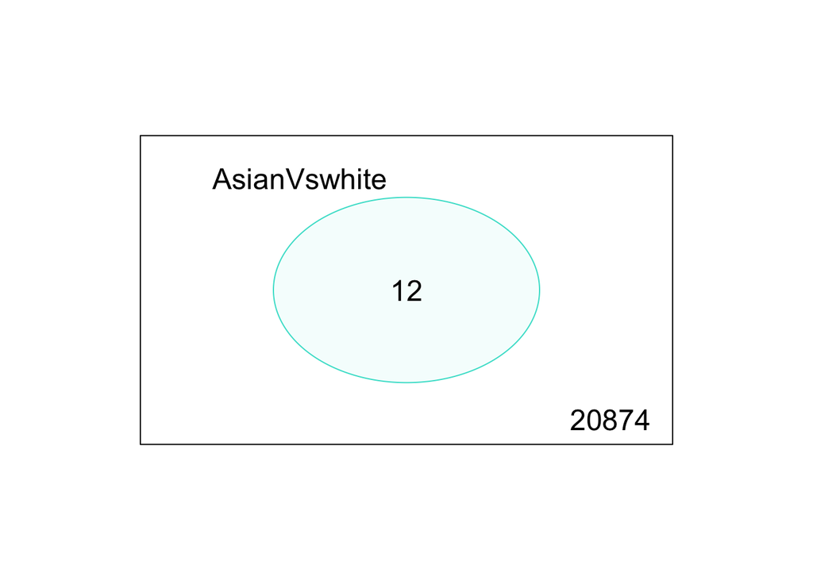

```r
vennDiagram(dt[,1], circle.col=c("turquoise", "salmon"))
```

```r
write.fit(tfit, dt, file="results.txt")
```

## Examining individual DE genes from top to bottom

The genes that are most differentially expressed can be listed using the topTreat function.

```r
Asian.vs.white <- topTreat(tfit, coef=1, n=Inf)
head(Asian.vs.white)
```

```
##                           ENSEMBL    SYMBOL TXCHROM     logFC   AveExpr
## ENSG00000239830.1 ENSG00000239830      <NA>    <NA> -4.746840 -2.464576
## ENSG00000207425.1 ENSG00000207425      <NA>    <NA> -4.300585 -3.207398
## ENSG00000274376.3 ENSG00000274376 ADAMTS7P1   chr15  1.933223 -3.163522
## ENSG00000226278.1 ENSG00000226278      <NA>    <NA>  6.037879 -1.366735
## ENSG00000171126.7 ENSG00000171126     KCNG3    chr2  2.407498 -2.904765
## ENSG00000223722.3 ENSG00000223722      <NA>    <NA>  3.386556 -1.755978
##                            t      P.Value    adj.P.Val
## ENSG00000239830.1 -14.036530 1.781817e-17 3.721503e-13
## ENSG00000207425.1  -6.325855 1.015147e-07 1.060118e-03
## ENSG00000274376.3   5.691024 6.692601e-07 4.659389e-03
## ENSG00000226278.1   5.130403 5.766105e-06 3.010772e-02
## ENSG00000171126.7   4.892766 9.893781e-06 3.968019e-02
## ENSG00000223722.3   4.872055 1.167377e-05 3.968019e-02
```

## Using graphical representations of differential expression results

To summarize the genes, the log fold change is plot against the log counts per million using the plotMD function.

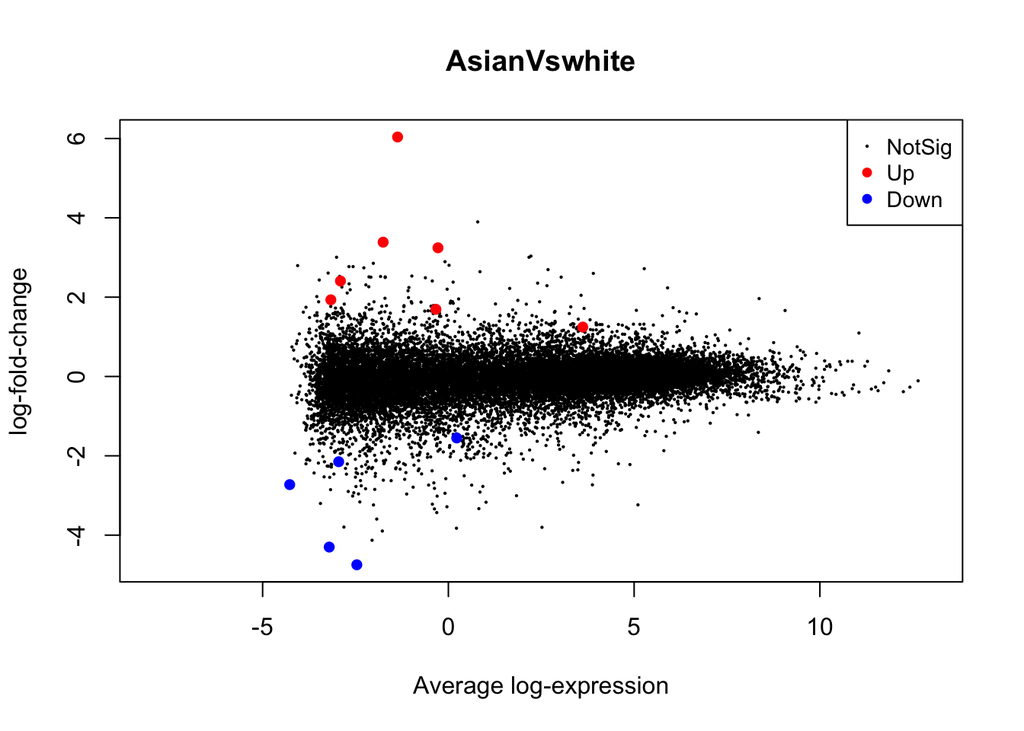

```r
plotMD(tfit, column=1, status=dt[,1], main=colnames(tfit)[1],
       xlim=c(-8,13))
```

A more interactive version of this plot can be created using Glimma.

```r
glMDPlot(tfit, coef=1, status=dt, main=colnames(tfit)[1],
         side.main="ENSEMBL", counts=lcpm, groups=group, launch=TRUE)
```

```r
library(gplots)
library(heatmap.plus)
```

Next, execute the following code:

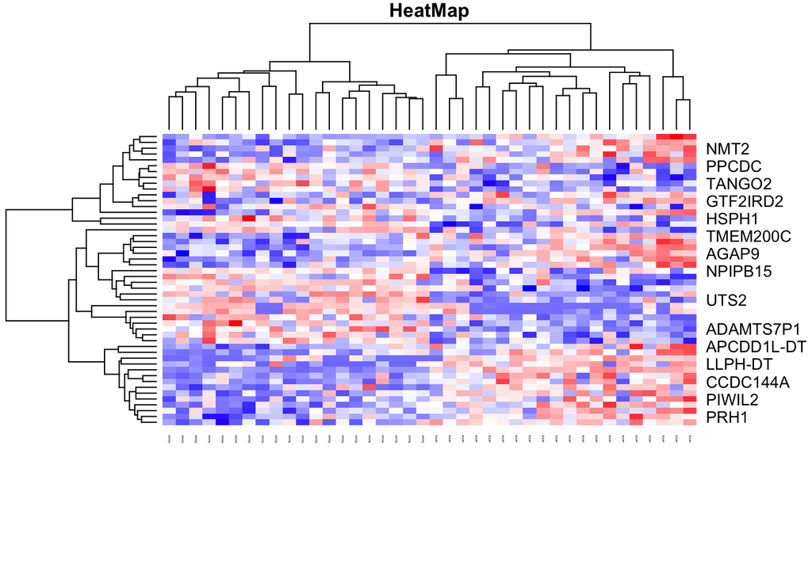

```r
Asian.vs.white.topgenes <- Asian.vs.white$ENSEMBL[1:50]
i <- which(v$genes$ENSEMBL %in% Asian.vs.white.topgenes)
mycol <- colorpanel(1000,"blue","white","red")
par(cex.main=0.8,mar=c(1,1,1,1))
heatmap.plus(lcpm[i,],  scale="row", labRow=v$genes$SYMBOL[i], labCol=group, col=mycol, cexRow=1,cexCol=0.2, margins = c(8,6), main="HeatMap")
```

In the heatmap produced, the red regions stand for up-regulated genes, blue regions represent down-regulated genes, and white presents intermediate levels of genes expression.

## Gene set testing with camera

The c2 curated gene set specific for humans needs to first be loaded into R. The human_c2_v5p2.rdata file will be used here, which is downloaded from the MSigDB collection. The names of the first few gene sets and the total number of gene sets are also observed.

```r
#Loading in the c2 curated gene set
load("human_c2_v5p2.rdata")

#Taking a look at the first couple of gene sets within the Homo sapiens c2 curated gene sets
names(Hs.c2)[1:5]
```

```
## [1] "KEGG_GLYCOLYSIS_GLUCONEOGENESIS"
## [2] "KEGG_CITRATE_CYCLE_TCA_CYCLE"
## [3] "KEGG_PENTOSE_PHOSPHATE_PATHWAY"
## [4] "KEGG_PENTOSE_AND_GLUCURONATE_INTERCONVERSIONS"
## [5] "KEGG_FRUCTOSE_AND_MANNOSE_METABOLISM"
```

```r
#Getting the total number of gene sets within Hs.c2
length(Hs.c2)
```

```
## [1] 4729
```

The gene IDs between the c2 gene sets and the v object defined previously are mapped together using the ids2indices function. A contrast matrix is created that compares the Asian patients data versus the white patients data. Finally, a barcode plot is generated that shows the enrichment of gene sets amongst the highly or lowly ranked genes between the Asian and white groups.

```r
idx <- ids2indices(Hs.c2, rownames(v$genes))
```

```r
cam.AsianVswhite <- camera(v,idx,design,contrast=contr.matrix[,1])
head(cam.AsianVswhite,7)
```

```
##                                          NGenes Direction       PValue      FDR
## IIZUKA_LIVER_CANCER_PROGRESSION_L1_G1_DN     10        Up 0.0003838099 0.997325
## REACTOME_PURINE_METABOLISM                   24        Up 0.0030587442 0.997325
## BIOCARTA_EXTRINSIC_PATHWAY                   11        Up 0.0041005617 0.997325
## REACTOME_SYNTHESIS_OF_PE                      4        Up 0.0044830374 0.997325
## REACTOME_PURINE_CATABOLISM                    5        Up 0.0046559967 0.997325
## XU_AKT1_TARGETS_48HR                          7        Up 0.0053271700 0.997325
## SMID_BREAST_CANCER_RELAPSE_IN_LUNG_UP        15        Up 0.0055492431 0.997325
```

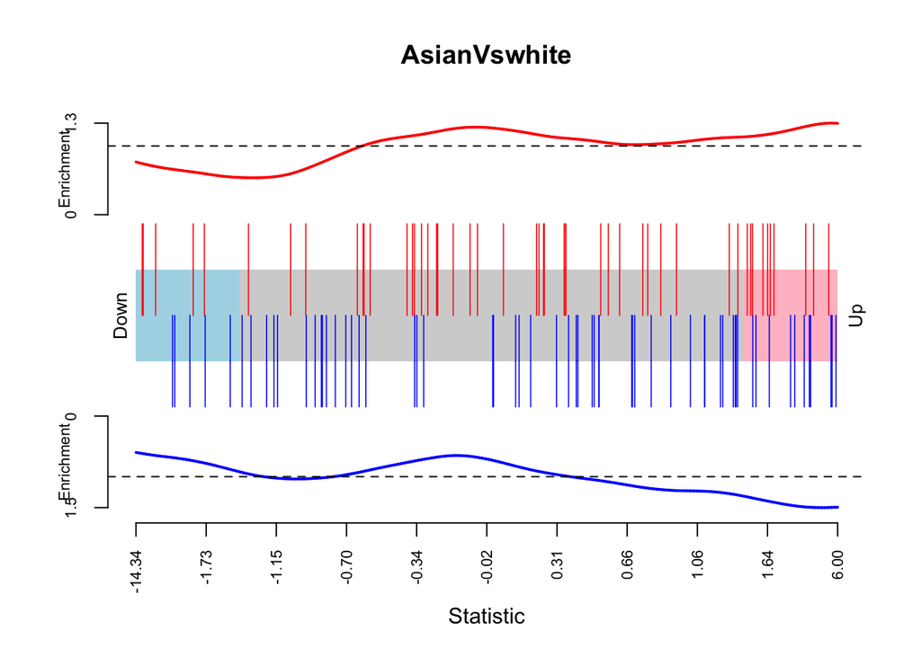

```r
barcodeplot(efit$t[,1], index=idx$LIM_MAMMARY_LUMINAL_MATURE_UP,
            index2=idx$LIM_MAMMARY_LUMINAL_MATURE_DN, main="AsianVswhite")
```